# 情報科学3

Rによる分類の例

矢内 勇生

2021-09-30

Rによる機械学習の例として、分類を行う方法を紹介する。各手法の説明は、今後の授業で行う。今回は、（どれくらいうまくいくかは別として）Rで分類が行えるということを確認する。

## 準備

必要なパッケージを読み込む。パッケージの読み込みには`pacman::p_load()` を使う。pacmanパッケージがインストール済みでない場合は、まずインストールする。

```r
if (!require(pacman)) install.packages("pacman")
pacman::p_load(tidyverse,
               palmerpenguins,  # データソース
               caret,           # 混同行列, kNN
               MASS,            # LDA
               nnet,            # 多項ロジスティック回帰
               e1071,           # SVM
               rpart,           # 決定木
               randomForest,    # ランダムフォレスト
               scales)          # expand_range()
```

次に、ggplot2のテーマとフォントの設定を行う。自分好みの設定がある場合は自由に変えてよい。Linuxには[IPAexフォント](https://moji.or.jp/ipafont/) がインストールされていることを想定している（IPAex はインストールすれば maxOSやWindows でも使える）。

```r
if (.Platform$OS.type == "windows") {
  if (require(fontregisterer)) {
    my_font <- "Yu Gothic"
  } else {
    my_font <- "Japan1"
  }
} else if (capabilities("aqua")) {
  my_font <- "HiraginoSans-W3"
} else {
  my_font <- "IPAexGothic"
}

theme_set(theme_gray(base_size = 9,
                     base_family = my_font))
```

## palmerpenguins データ

今回は、[**palmerpenguins**パッケージ](https://allisonhorst.github.io/palmerpenguins/)の`penguins`データを使う。

```r
data(penguins)
```

データセットの詳細は`?penguins` で確認できる。

いくつかの方法で、データの中身を確認してみよう。 まず、データセットのサイズ（次元, 行数と列数）を確認する。

```r
dim(penguins)
```

```
## [1] 344   8
```

行数（観測数, サンプルサイズ）。

```r
nrow(penguins)
```

```
## [1] 344
```

列数（変数の数）。

```r
ncol(penguins)
```

```
## [1] 8
```

変数名（列名）。

```r
names(penguins)
```

```
## [1] "species"           "island"            "bill_length_mm"
## [4] "bill_depth_mm"     "flipper_length_mm" "body_mass_g"
## [7] "sex"               "year"
```

データセットの基本情報を確認する。データセットを読み込んだ直後に、毎回これを実行することを推奨。ただし、R Markdown ファイルには書かない（あるいはチャンクオプションで `eval = FALSE` を指定する）ほうがいいかもしれない。

```r
glimpse(penguins)
```

```
## Rows: 344
## Columns: 8
## $ species           <fct> Adelie, Adelie, Adelie, Adelie, Adelie, Adelie, Adel…
## $ island            <fct> Torgersen, Torgersen, Torgersen, Torgersen, Torgerse…
## $ bill_length_mm    <dbl> 39.1, 39.5, 40.3, NA, 36.7, 39.3, 38.9, 39.2, 34.1, …
## $ bill_depth_mm     <dbl> 18.7, 17.4, 18.0, NA, 19.3, 20.6, 17.8, 19.6, 18.1, …
## $ flipper_length_mm <int> 181, 186, 195, NA, 193, 190, 181, 195, 193, 190, 186…
## $ body_mass_g       <int> 3750, 3800, 3250, NA, 3450, 3650, 3625, 4675, 3475, …
## $ sex               <fct> male, female, female, NA, female, male, female, male…
## $ year              <int> 2007, 2007, 2007, 2007, 2007, 2007, 2007, 2007, 2007…
```

同上（tidyverse を読み込まなくても使える）。

```r
str(penguins)
```

```
## tibble [344 × 8] (S3: tbl_df/tbl/data.frame)
##  $ species          : Factor w/ 3 levels "Adelie","Chinstrap",..: 1 1 1 1 1 1 1 1 1 1 ...
##  $ island           : Factor w/ 3 levels "Biscoe","Dream",..: 3 3 3 3 3 3 3 3 3 3 ...
##  $ bill_length_mm   : num [1:344] 39.1 39.5 40.3 NA 36.7 39.3 38.9 39.2 34.1 42 ...
##  $ bill_depth_mm    : num [1:344] 18.7 17.4 18 NA 19.3 20.6 17.8 19.6 18.1 20.2 ...
##  $ flipper_length_mm: int [1:344] 181 186 195 NA 193 190 181 195 193 190 ...
##  $ body_mass_g      : int [1:344] 3750 3800 3250 NA 3450 3650 3625 4675 3475 4250 ...
##  $ sex              : Factor w/ 2 levels "female","male": 2 1 1 NA 1 2 1 2 NA NA ...
##  $ year             : int [1:344] 2007 2007 2007 2007 2007 2007 2007 2007 2007 2007 ...
```

データセットの先頭部（最初の$n$ 行。デフォルトは`n=6`）を表示。

```r
head(penguins)
```

```
## # A tibble: 6 × 8
##   species island bill_length_mm bill_depth_mm flipper_length_… body_mass_g sex
##   <fct>   <fct>           <dbl>         <dbl>            <int>       <int> <fct>
## 1 Adelie  Torge…           39.1          18.7              181        3750 male
## 2 Adelie  Torge…           39.5          17.4              186        3800 fema…
## 3 Adelie  Torge…           40.3          18                195        3250 fema…
## 4 Adelie  Torge…           NA            NA                 NA          NA <NA>
## 5 Adelie  Torge…           36.7          19.3              193        3450 fema…
## 6 Adelie  Torge…           39.3          20.6              190        3650 male
## # … with 1 more variable: year <int>
```

データセットの最後部（最後の$n$ 行。デフォルトは`n=6`）を表示。

```r
tail(penguins, n = 3)
```

```
## # A tibble: 3 × 8
##   species island bill_length_mm bill_depth_mm flipper_length_… body_mass_g sex
##   <fct>   <fct>           <dbl>         <dbl>            <int>       <int> <fct>
## 1 Chinst… Dream            49.6          18.2              193        3775 male
## 2 Chinst… Dream            50.8          19                210        4100 male
## 3 Chinst… Dream            50.2          18.7              198        3775 fema…
## # … with 1 more variable: year <int>
```

基本的な記述統計を表示。

```r
summary(penguins)
```

```
##       species          island    bill_length_mm  bill_depth_mm
##  Adelie   :152   Biscoe   :168   Min.   :32.10   Min.   :13.10
##  Chinstrap: 68   Dream    :124   1st Qu.:39.23   1st Qu.:15.60
##  Gentoo   :124   Torgersen: 52   Median :44.45   Median :17.30
##                                  Mean   :43.92   Mean   :17.15
##                                  3rd Qu.:48.50   3rd Qu.:18.70
##                                  Max.   :59.60   Max.   :21.50
##                                  NA's   :2       NA's   :2
##  flipper_length_mm  body_mass_g       sex           year
##  Min.   :172.0     Min.   :2700   female:165   Min.   :2007
##  1st Qu.:190.0     1st Qu.:3550   male  :168   1st Qu.:2007
##  Median :197.0     Median :4050   NA's  : 11   Median :2008
##  Mean   :200.9     Mean   :4202                Mean   :2008
##  3rd Qu.:213.0     3rd Qu.:4750                3rd Qu.:2009
##  Max.   :231.0     Max.   :6300                Max.   :2009
##  NA's   :2         NA's   :2
```

## 問題の設定

今回は、くちばしの長さ (`bill_length_mm`) と くちばしの厚み (`bill_depth_mm`) からペンギンの種類 (`species`) を予測（分類）する。

```r
with(penguins, table(species))
```

```
## species
##    Adelie Chinstrap    Gentoo
##       152        68       124
```

種類が英語で記録されているので日本語に変え、利用する3つの変数のなかに欠測値があるものを（とりあえず）取り除く。

```r
penguins_s1 <- penguins %>%
  mutate(species = case_when(
    species == "Adelie"    ~ 1L,
    species == "Chinstrap" ~ 2L,
    TRUE                   ~ 3L,
  )) %>%
  mutate(species = factor(species,
                          levels = 1:3,
                          labels = c("アデリー", "ヒゲ", "ジェンツー"))) %>%
  dplyr::select(species, bill_length_mm, bill_depth_mm) %>%
  na.omit()
```

予測に使う2つの変数（機械学習ではこれを**特徴量 (feature)**と呼ぶ）と、実際の種類（つまり、分類問題の正解。機械学習における分類問題ではこれを**ラベル (label)**と呼ぶ）の関係を図示する。

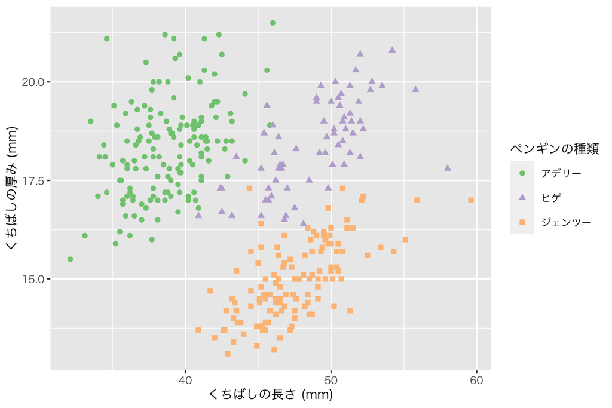

```r
p1 <- ggplot(penguins_s1,
             aes(x = bill_length_mm,
                 y = bill_depth_mm)) +
  geom_point(aes(color = species,
                 shape = species)) +
  scale_color_brewer(palette = "Accent") +
  labs(x = "くちばしの長さ (mm)",
       y = "くちばしの厚み (mm)",
       color = "ペンギンの種類",
       shape = "ペンギンの種類")
plot(p1)
```

予測に使うRのformulaを用意しておこう。 `species` を `bill_length_mm` と `bill_depth_mm` から予測する（`species` を `bill_length_mm` と `bill_depth_mm` に回帰する）。

```r
pgnf <- formula(species ~ bill_length_mm + bill_depth_mm)
```

分類の境界線 (decision boundaries; discrimination lines) を求める範囲のグリッドデータを用意しておく。

```r
bill_len_lim <- range(penguins_s1$bill_length_mm) %>%
  expand_range(mul = 0.05)
bill_dep_lim <- range(penguins_s1$bill_depth_mm) %>%
  expand_range(mul = 0.05)
newdf <- expand_grid(
  bill_length_mm = seq(bill_len_lim[1], bill_len_lim[2], length.out = 500),
  bill_depth_mm = seq(bill_dep_lim[1], bill_dep_lim[2], length.out = 500)
)
glimpse(newdf, n = 5)
```

```
## Rows: 250,000
## Columns: 2
## $ bill_length_mm <dbl> 30.725, 30.725, 30.725, 30.725, 30.725, 30.725, 30.725,…
## $ bill_depth_mm  <dbl> 12.68000, 12.69852, 12.71703, 12.73555, 12.75407, 12.77…
```

これからいくつかの方法で分類を行い、そのたびに上で作った散布図に、分類の境界線を上書きした図を作る。繰り返し行う作業は関数化してしまったほうが効率が良い。 そこで、分類結果を図示するための関数`decision_region()`を自作する。

```r
decision_region <- function(pred_class, title = NULL) {
  # pred_class には予測（分類）結果を数値で表したベクトルを渡す
  df <- newdf %>%
    mutate(predicted = pred_class)
  p <- p1 +
    geom_raster(data = df,
                aes(fill = as.factor(predicted)),
                alpha = 0.2,
                show.legend = FALSE) +
    geom_contour(data = df,
                 aes(z = predicted),
                 color = "gray") +
    scale_fill_brewer(palette = "Accent") +
    scale_x_continuous(limits = bill_len_lim, expand = c(0, 0)) +
    scale_y_continuous(limits = bill_dep_lim, expand = c(0, 0)) +
    ggtitle(title)
  return(p)
}
```

## LDA（線形判別分析）

LDA (Linear Discriminant Analysis) で分類してみよう。`MASS::lda()`を使う。

```r
classifier_lda <- lda(pgnf, data = penguins_s1)
```

予測（分類）がどれだけうまくできたか確認するために、混同行列 (confusion matrix) を表示する。 `predict()` で予測を行い、`caret::confusionMatrix()` で混同行列を作る。

```r
pred_lda <- predict(classifier_lda)
confusionMatrix(pred_lda$class,
                reference = penguins_s1$species)
```

```
## Confusion Matrix and Statistics
##
##             Reference
## Prediction   アデリー ヒゲ ジェンツー
##   アデリー        149    5          0
##   ヒゲ              2   59          2
##   ジェンツー        0    4        121
##
## Overall Statistics
##
##                Accuracy : 0.962
##                  95% CI : (0.9359, 0.9796)
##     No Information Rate : 0.4415
##     P-Value [Acc > NIR] : < 2.2e-16
##
##                   Kappa : 0.94
##
##  Mcnemar's Test P-Value : NA
##
## Statistics by Class:
##
##                      Class: アデリー Class: ヒゲ Class: ジェンツー
## Sensitivity                   0.9868      0.8676            0.9837
## Specificity                   0.9738      0.9854            0.9817
## Pos Pred Value                0.9675      0.9365            0.9680
## Neg Pred Value                0.9894      0.9677            0.9908
## Prevalence                    0.4415      0.1988            0.3596
## Detection Rate                0.4357      0.1725            0.3538
## Detection Prevalence          0.4503      0.1842            0.3655
## Balanced Accuracy             0.9803      0.9265            0.9827
```

Prediction が予測結果、Reference が正解である。Accuracy に予測の正解率が示されている。他の部分の読み方については、今後の授業で説明する。

分類の境界線 (decision boundaries; discrimination lines) を図示する。

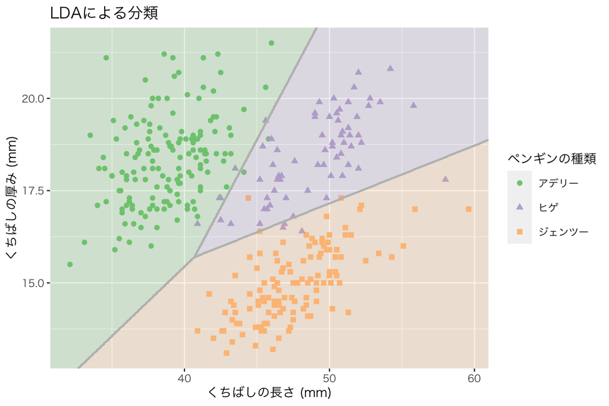

```r
p_lda <- predict(classifier_lda, newdata = newdf)$class %>%
  as.numeric() %>%
  decision_region(title = "LDAによる分類")
plot(p_lda)
```

## ロジスティック回帰

ロジスティック回帰による分類を行う。分類するカテゴリが3つあるので、多項ロジスティック回帰 (multinomial logistic regression) を利用する。`nnet::multinom()`を使う。

```r
classifier_logit <- multinom(pgnf, data = penguins_s1)
```

混同行列。

```r
predict(classifier_logit) %>%
  confusionMatrix(reference = penguins_s1$species)
```

```
## Confusion Matrix and Statistics
##
##             Reference
## Prediction   アデリー ヒゲ ジェンツー
##   アデリー        148    3          0
##   ヒゲ              3   61          2
##   ジェンツー        0    4        121
##
## Overall Statistics
##
##                Accuracy : 0.9649
##                  95% CI : (0.9395, 0.9817)
##     No Information Rate : 0.4415
##     P-Value [Acc > NIR] : < 2.2e-16
##
##                   Kappa : 0.9448
##
##  Mcnemar's Test P-Value : NA
##
## Statistics by Class:
##
##                      Class: アデリー Class: ヒゲ Class: ジェンツー
## Sensitivity                   0.9801      0.8971            0.9837
## Specificity                   0.9843      0.9818            0.9817
## Pos Pred Value                0.9801      0.9242            0.9680
## Neg Pred Value                0.9843      0.9746            0.9908
## Prevalence                    0.4415      0.1988            0.3596
## Detection Rate                0.4327      0.1784            0.3538
## Detection Prevalence          0.4415      0.1930            0.3655
## Balanced Accuracy             0.9822      0.9394            0.9827
```

分類の境界線を図示する。

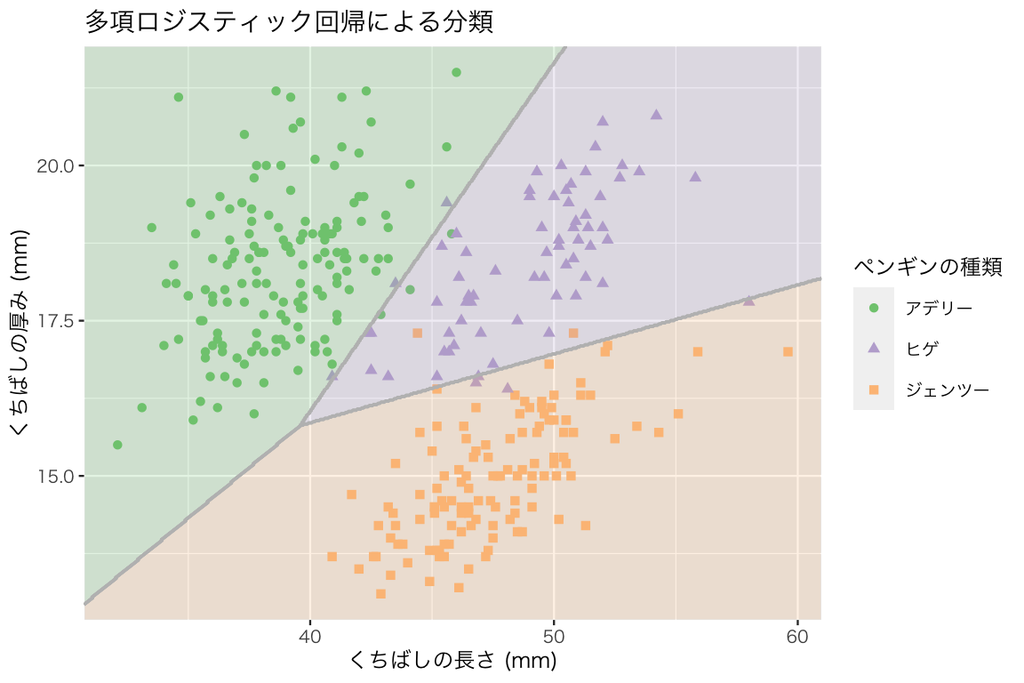

```r
p_logit <- predict(classifier_logit, newdata = newdf) %>%
  as.numeric() %>%
  decision_region(title = "多項ロジスティック回帰による分類")
plot(p_logit)
```

## SVM（サポートベクタマシン）

SVM (support vector machine) による分類を行う。 `e1071::svm()` を使う。`kernel`引数で利用するカーネルを指定する。

### 線形カーネル

線形カーネル (linear kernel) を使ってSVMで分類を行う。

```r
svm_linear <- svm(pgnf,
                  data = penguins_s1,
                  kernel = "linear")
```

混同行列。

```r
predict(svm_linear) %>%
  confusionMatrix(reference = penguins_s1$species)
```

```
## Confusion Matrix and Statistics
##
##             Reference
## Prediction   アデリー ヒゲ ジェンツー
##   アデリー        149    5          0
##   ヒゲ              2   60          3
##   ジェンツー        0    3        120
##
## Overall Statistics
##
##                Accuracy : 0.962
##                  95% CI : (0.9359, 0.9796)
##     No Information Rate : 0.4415
##     P-Value [Acc > NIR] : < 2.2e-16
##
##                   Kappa : 0.94
##
##  Mcnemar's Test P-Value : NA
##
## Statistics by Class:
##
##                      Class: アデリー Class: ヒゲ Class: ジェンツー
## Sensitivity                   0.9868      0.8824            0.9756
## Specificity                   0.9738      0.9818            0.9863
## Pos Pred Value                0.9675      0.9231            0.9756
## Neg Pred Value                0.9894      0.9711            0.9863
## Prevalence                    0.4415      0.1988            0.3596
## Detection Rate                0.4357      0.1754            0.3509
## Detection Prevalence          0.4503      0.1901            0.3596
## Balanced Accuracy             0.9803      0.9321            0.9810
```

**e1071**パッケージには、分類境界を可視化する関数が用意されている。

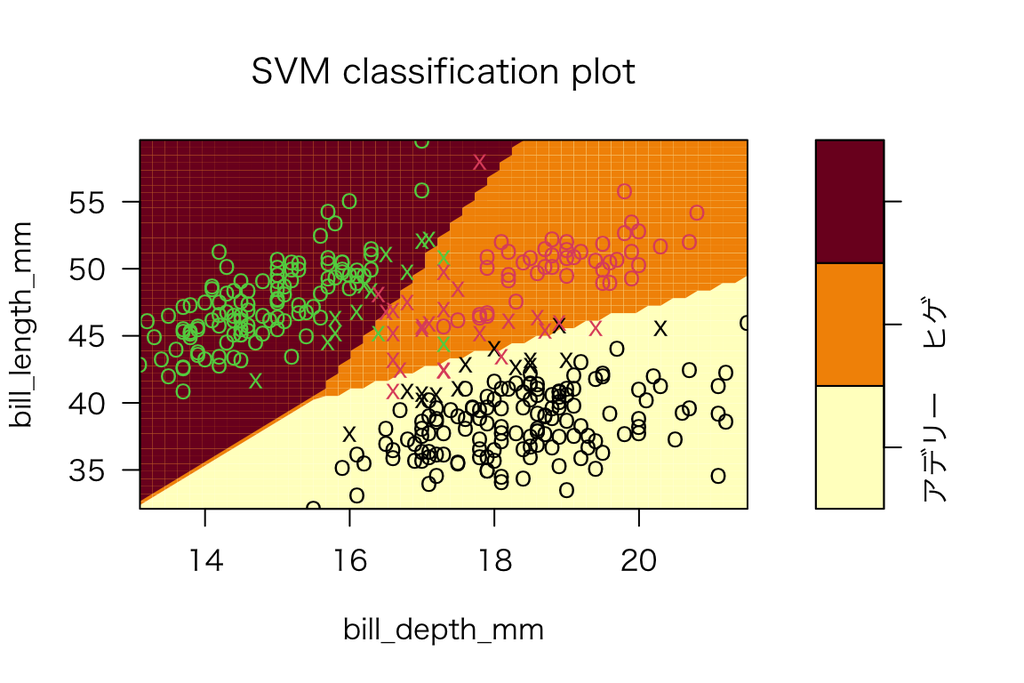

```r
par(family = my_font)
plot(svm_linear, data = penguins_s1)
```

横軸と縦軸が入れ替わっている。

ggplot2 で描き直す。

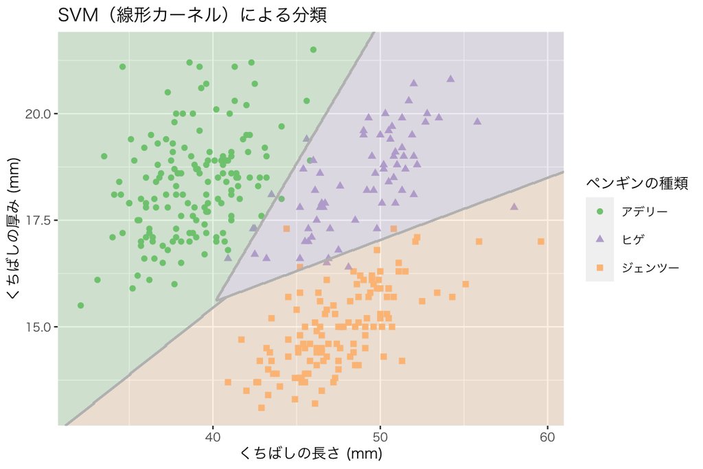

```r
p_svm_linear <- predict(svm_linear, newdata = newdf) %>%
  as.numeric() %>%
  decision_region(title = "SVM（線形カーネル）による分類")
plot(p_svm_linear)
```

### ガウスカーネル

ガウスカーネル (Gaussian kernel or radial basis function; RBF) を使う。 `gamma`引数で、関数の複雑さ（円の曲率）を調整する。大きな値にするほど、複雑な関数を使った分類になる。 まず、`gamma = 0.5`でやってみる。

```r
svm_rbf1 <- svm(pgnf,
                data = penguins_s1,
                kernel = "radial",
                gamma = 0.5)  # 関数の複雑さを決めるパラメタ
```

混同行列。

```r
predict(svm_rbf1) %>%
  confusionMatrix(reference = penguins_s1$species)
```

```
## Confusion Matrix and Statistics
##
##             Reference
## Prediction   アデリー ヒゲ ジェンツー
##   アデリー        149    5          0
##   ヒゲ              2   60          3
##   ジェンツー        0    3        120
##
## Overall Statistics
##
##                Accuracy : 0.962
##                  95% CI : (0.9359, 0.9796)
##     No Information Rate : 0.4415
##     P-Value [Acc > NIR] : < 2.2e-16
##
##                   Kappa : 0.94
##
##  Mcnemar's Test P-Value : NA
##
## Statistics by Class:
##
##                      Class: アデリー Class: ヒゲ Class: ジェンツー
## Sensitivity                   0.9868      0.8824            0.9756
## Specificity                   0.9738      0.9818            0.9863
## Pos Pred Value                0.9675      0.9231            0.9756
## Neg Pred Value                0.9894      0.9711            0.9863
## Prevalence                    0.4415      0.1988            0.3596
## Detection Rate                0.4357      0.1754            0.3509
## Detection Prevalence          0.4503      0.1901            0.3596
## Balanced Accuracy             0.9803      0.9321            0.9810
```

分類境界を図示する。

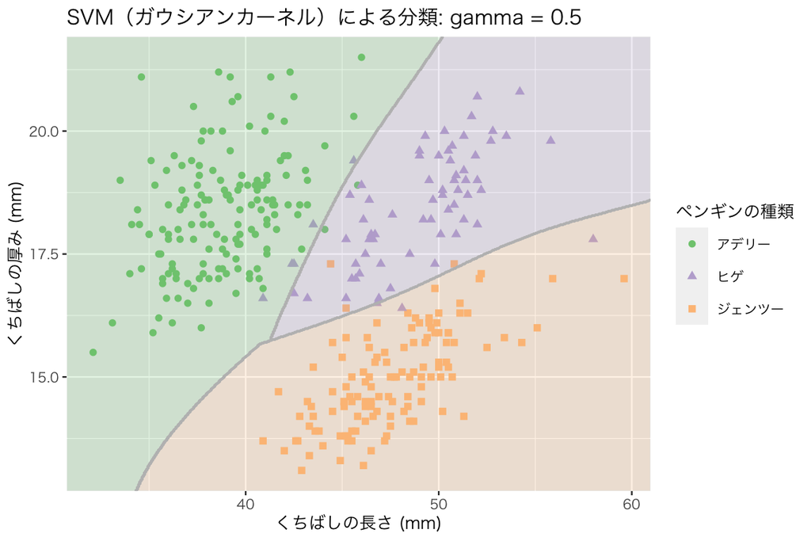

```r
p_svm_rbf1 <- predict(svm_rbf1, newdata = newdf) %>%
  as.numeric() %>%
  decision_region(title = "SVM（ガウシアンカーネル）による分類: gamma = 0.5")
plot(p_svm_rbf1)
```

境界線が直線ではなくなったことがわかる。

次に、`gamma = 10` にしてみる。

```r
svm_rbf2 <- svm(pgnf,
                data = penguins_s1,
                kernel = "radial",
                gamma = 10)  # 関数の複雑さを決めるパラメタ
```

混同行列。

```r
predict(svm_rbf2) %>%
  confusionMatrix(reference = penguins_s1$species)
```

```
## Confusion Matrix and Statistics
##
##             Reference
## Prediction   アデリー ヒゲ ジェンツー
##   アデリー        149    2          0
##   ヒゲ              2   65          2
##   ジェンツー        0    1        121
##
## Overall Statistics
##
##                Accuracy : 0.9795
##                  95% CI : (0.9583, 0.9917)
##     No Information Rate : 0.4415
##     P-Value [Acc > NIR] : < 2.2e-16
##
##                   Kappa : 0.9679
##
##  Mcnemar's Test P-Value : NA
##
## Statistics by Class:
##
##                      Class: アデリー Class: ヒゲ Class: ジェンツー
## Sensitivity                   0.9868      0.9559            0.9837
## Specificity                   0.9895      0.9854            0.9954
## Pos Pred Value                0.9868      0.9420            0.9918
## Neg Pred Value                0.9895      0.9890            0.9909
## Prevalence                    0.4415      0.1988            0.3596
## Detection Rate                0.4357      0.1901            0.3538
## Detection Prevalence          0.4415      0.2018            0.3567
## Balanced Accuracy             0.9881      0.9706            0.9896
```

分類境界を図示する。

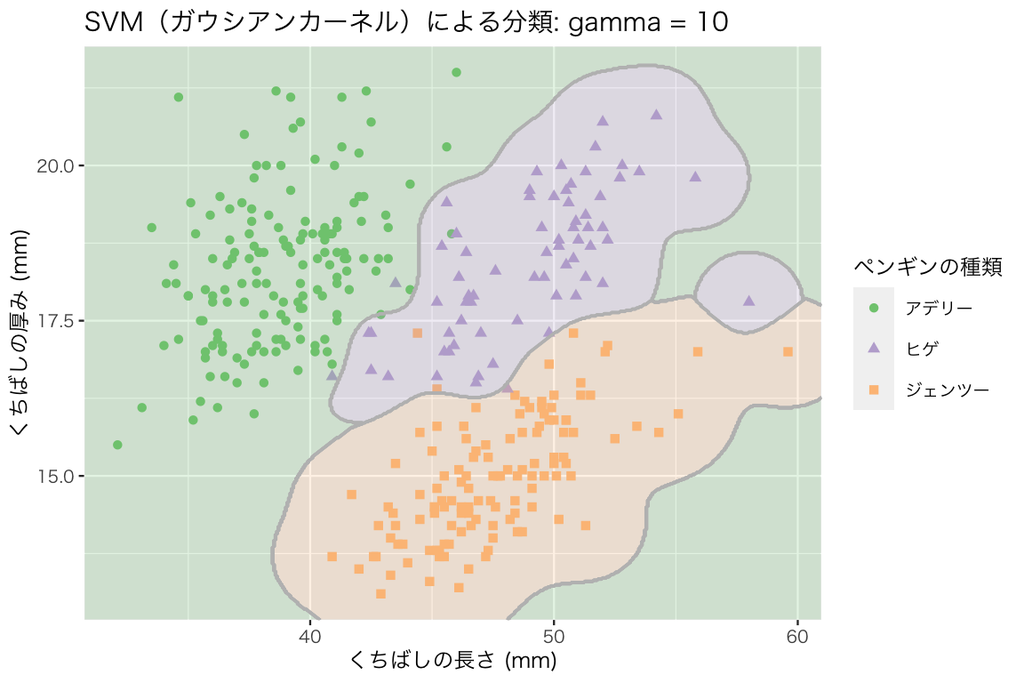

```r
p_svm_rbf2 <- predict(svm_rbf2, newdata = newdf) %>%
  as.numeric() %>%
  decision_region(title = "SVM（ガウシアンカーネル）による分類: gamma = 10")
plot(p_svm_rbf2)
```

先程よりも複雑な境界線が引かれている。その結果、観測データの分類がうまくできている一方で、グラフの右下や右上が緑色（アデリーペンギン）と予測（分類）されており、関数を複雑にし過ぎると弊害がありそうだということがわかる。

## 決定木

決定木 (decision tree) による分類を行う。 `rpart::rpart()` を使う。

```r
classifier_tree <- rpart(pgnf, data = penguins_s1)
```

混同行列。

```r
predict(classifier_tree, type = "class") %>%
  confusionMatrix(reference = penguins_s1$species)
```

```
## Confusion Matrix and Statistics
##
##             Reference
## Prediction   アデリー ヒゲ ジェンツー
##   アデリー        148    6          4
##   ヒゲ              3   62          8
##   ジェンツー        0    0        111
##
## Overall Statistics
##
##                Accuracy : 0.9386
##                  95% CI : (0.9077, 0.9616)
##     No Information Rate : 0.4415
##     P-Value [Acc > NIR] : < 2.2e-16
##
##                   Kappa : 0.9036
##
##  Mcnemar's Test P-Value : 0.004637
##
## Statistics by Class:
##
##                      Class: アデリー Class: ヒゲ Class: ジェンツー
## Sensitivity                   0.9801      0.9118            0.9024
## Specificity                   0.9476      0.9599            1.0000
## Pos Pred Value                0.9367      0.8493            1.0000
## Neg Pred Value                0.9837      0.9777            0.9481
## Prevalence                    0.4415      0.1988            0.3596
## Detection Rate                0.4327      0.1813            0.3246
## Detection Prevalence          0.4620      0.2135            0.3246
## Balanced Accuracy             0.9639      0.9358            0.9512
```

分類境界を図示する。

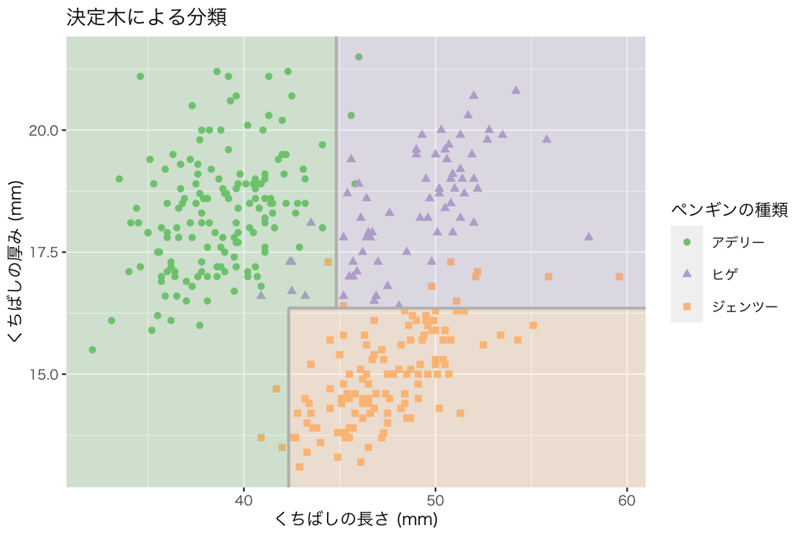

```r
p_tree <- predict(classifier_tree,
                  newdata = newdf,
                  type = "class") %>%
  as.numeric() %>%
  decision_region(title = "決定木による分類")
plot(p_tree)
```

境界線がそれぞれの特徴量（説明変数）の軸と垂直（平行）に引かれていることがわかる。

## ランダムフォレスト

ランダムフォレスト (random forest) による分類を行う。`randomForest::randomForest()` を使う。`ntree` 引数で、いくつの決定木を使うかを決める。

```r
classifier_rf <- randomForest(pgnf,
                              data = penguins_s1,
                              ntree = 50)
```

混同行列。

```r
predict(classifier_rf) %>%
  confusionMatrix(reference = penguins_s1$species)
```

```
## Confusion Matrix and Statistics
##
##             Reference
## Prediction   アデリー ヒゲ ジェンツー
##   アデリー        149    3          0
##   ヒゲ              2   63          4
##   ジェンツー        0    2        119
##
## Overall Statistics
##
##                Accuracy : 0.9678
##                  95% CI : (0.9432, 0.9838)
##     No Information Rate : 0.4415
##     P-Value [Acc > NIR] : < 2.2e-16
##
##                   Kappa : 0.9495
##
##  Mcnemar's Test P-Value : NA
##
## Statistics by Class:
##
##                      Class: アデリー Class: ヒゲ Class: ジェンツー
## Sensitivity                   0.9868      0.9265            0.9675
## Specificity                   0.9843      0.9781            0.9909
## Pos Pred Value                0.9803      0.9130            0.9835
## Neg Pred Value                0.9895      0.9817            0.9819
## Prevalence                    0.4415      0.1988            0.3596
## Detection Rate                0.4357      0.1842            0.3480
## Detection Prevalence          0.4444      0.2018            0.3538
## Balanced Accuracy             0.9855      0.9523            0.9792
```

分類境界を図示する。

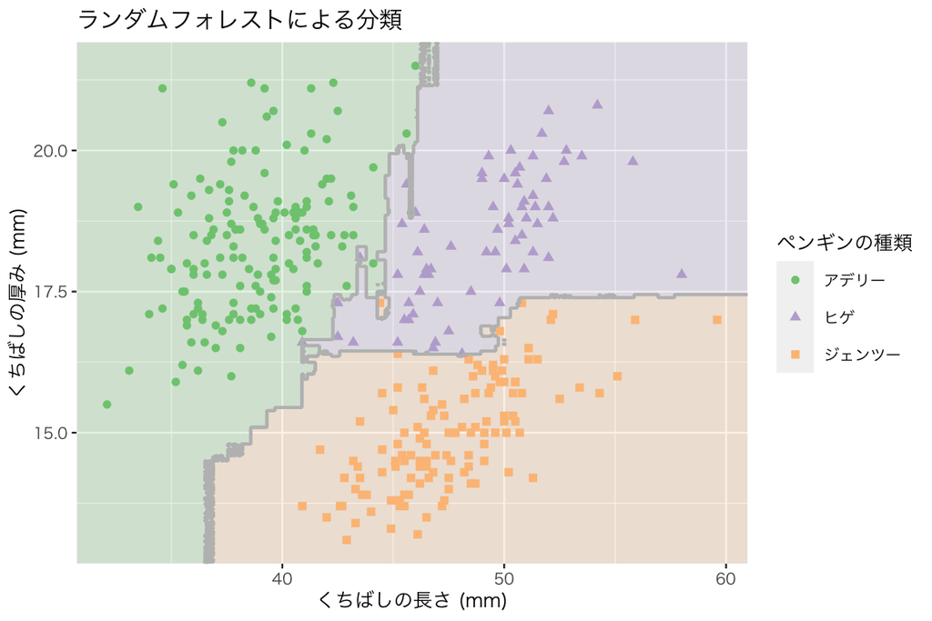

```r
p_rf <- predict(classifier_rf,
                newdata = newdf,
                type = "class") %>%
  as.numeric() %>%
  decision_region(title = "ランダムフォレストによる分類")
plot(p_rf)
```

決定木と比較すると、複雑な境界線になることがわかる。

# $k$近傍法による分類

$k$近傍 ($k$-nearest neighbor; kNN) 法による分類を行う。 `caret::knn3()` を使う。

```r
classifier_kNN <- knn3(pgnf,
                       data = penguins_s1,
                       k = 5)
```

混同行列。

```r
predict(classifier_kNN, newdata = penguins_s1, type = "class") %>%
  confusionMatrix(reference = penguins_s1$species)
```

```
## Confusion Matrix and Statistics
##
##             Reference
## Prediction   アデリー ヒゲ ジェンツー
##   アデリー        149    2          0
##   ヒゲ              2   64          3
##   ジェンツー        0    2        120
##
## Overall Statistics
##
##                Accuracy : 0.9737
##                  95% CI : (0.9506, 0.9879)
##     No Information Rate : 0.4415
##     P-Value [Acc > NIR] : < 2.2e-16
##
##                   Kappa : 0.9587
##
##  Mcnemar's Test P-Value : NA
##
## Statistics by Class:
##
##                      Class: アデリー Class: ヒゲ Class: ジェンツー
## Sensitivity                   0.9868      0.9412            0.9756
## Specificity                   0.9895      0.9818            0.9909
## Pos Pred Value                0.9868      0.9275            0.9836
## Neg Pred Value                0.9895      0.9853            0.9864
## Prevalence                    0.4415      0.1988            0.3596
## Detection Rate                0.4357      0.1871            0.3509
## Detection Prevalence          0.4415      0.2018            0.3567
## Balanced Accuracy             0.9881      0.9615            0.9832
```

分類境界を図示する。

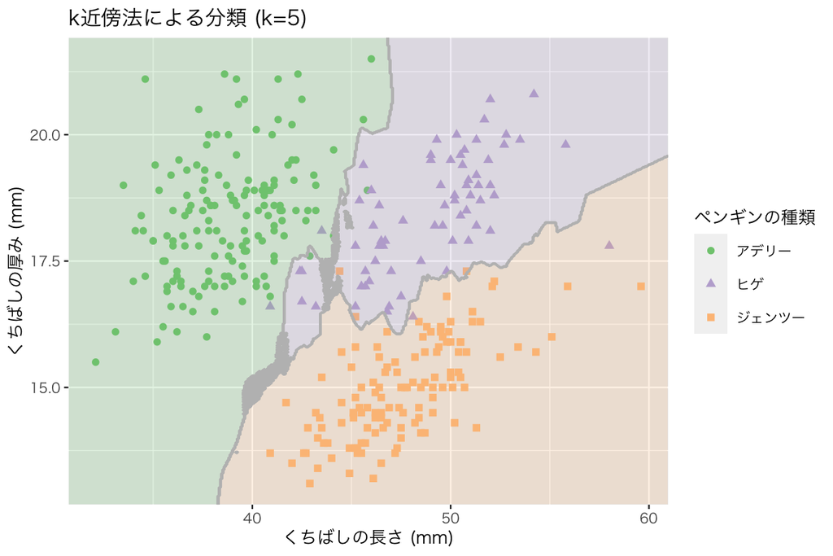

```r
p_kNN <- predict(classifier_kNN,
                 newdata = newdf,
                 type = "class") %>%
  as.numeric() %>%
  decision_region(title = "k近傍法による分類 (k=5)")
plot(p_kNN)
```

このように、Rを使うとさまざまな方法で分類を行うことができる（もちろんPythonでもできるが、機械学習の基本的な問題については、Rだけでも対処できる。RもPythonも使えるのが理想）。方法ごとに異なるパッケージを利用することになるが、それぞれの方法に固有のパラメタ（引数）の指定が必要だという点を除けば、基本的な使い方はほぼ同じである。

ここで実行した分類を、引数（たとえば、`svm()` の`gamma`や `knn3()` の`k`）の値を変えて実行してみよう。どのような結果が得られるだろうか。

授業の内容に戻る